# oDCM - Course Summary & Exam Preparation

Hannes Datta

### Welcome to the final lecture in oDCM!

If you haven't done so, please **explore the exam page & example questions** at https://odcm.hannesdatta.com/docs/exam.

The **course evaluation** is live at https://app.evalytics.nl. Please voice your opinions!

### Agenda

- Course summary
- From here onwards
  - Recognizing limitations
  - Seizing research opportunities
- Course evaluation
- Exam preparation
- Remaining questions

### Positioning in the study program

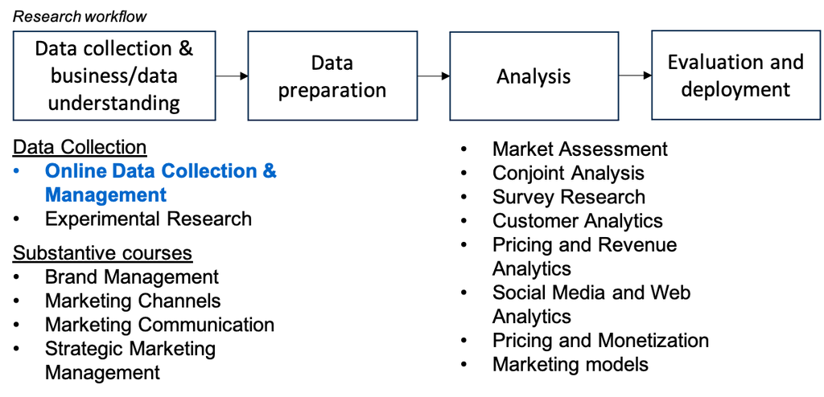

### Lessons learnt #1: Why to use web data?

- Research is by far more impactful than non-webdata-based research
  - Explore novel phenomena, be timely!
  - Boost ecological value, get closer to what managers use and are interested in!
  - Facilitate methodological advancement (e.g., text, images, video)
  - Better measurement (e.g., control variables)
- But: challenging!
  - Programming skills to master technical challenges
  - Conceptual thinking to navigate design choices & legal risks

### Lessons learnt #2: Staying in balance

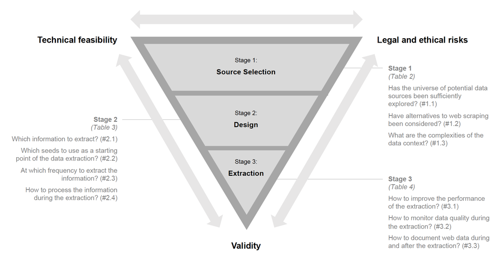

**Let's generate a few examples where validity, legal and technical goals conflicted in your projects.**

### Lessons learnt #3: Data Source Selection

- Important of “broadening horizon” (e.g., assume perspective of various stakeholders, exceed geographical boundaries, use aggregators rather than primary data providers)
- Consider alternatives to scraping (i.e., avoid defaulting! e.g., APIs, but also ready-made data sets)
- Scope the data context (i.e., understand how the data is generated, assess reliability of the data, explore user conversations about the data, etc.)

### Lessons learnt #4: Design Challenges (I)

- Look out for information - especially the “surprising ones!”
- Look out for *variables* (e.g., to compare to other studies), but also to see *time availability* differences
- Spend time mapping your navigation path
- Real-time data collection required?! (e.g., wrong historical data, inaccurate timestamps?)
- Algorithmic biases present? Can exert control?

### Lessons learnt #5: Design Challenges (II)

- How long does the data collection run?
- How to sample/seed?
- To which population do the seeds generalize?
- At what frequency to extract the data (e.g., once? multiple times?)
- How to process the data on-the-fly? (e.g., first store as JSON, then parse; pandas-based parsing)

### Lessons learnt #6: Design Challenges (III)

- Scientific purpose, and run by research institution?
- Scale and scope? (all data vs. small sample? running time)
- Location of data provider and users
- “Go” decision from provider? Technical intrusiveness?
- Data management & use, commercialization

### Lessons learnt #7: Extraction

- Prototyping is extremely important
  - `requests` + `beautifulSoup` vs. `selenium` (Chromedriver)
  - extraction methodology (e.g., tags, classes or other attributes, capturing `.get_text()` vs. the values of attributes) + stability
  - array misalignment (obey the hierarchy of stuff/how it is structured!!!)
  - scheduling, hiding passwords
  - revise navigation paths
  - add comments to code (make it understandable for others, e.g., using ChatGPT)
- Start documentation from a readme template
  - Generate plots, descriptive stats
  - Think as a “data supplier” rather than narrowly focusing on *one* (research) question

### Lessons learnt #8: Web Scraping in Retailing

- Based on Guyt et al. 2024
- Research opportunities
- Hands-on-framework: Extraction, Looping, Timing, Infrastructure
- Challenges & Opportunities for Retail Scraping
  - Overcoming matching challenges and time alignment
  - LLMs for web scraping

### Looking ahead: Recognizing Limitations

- Web data entails modeling challenges - not covered in this course (e.g., self-selection, endogeneity, “messy” data)
- Web data can't give you all (i.e., it *looks* l ike internal clickstream data, but it is not)
- Legal and ethical issues not fully explored

### Potential Applications

- Collecting data for Master thesis
  - tell my colleagues you have the skills
  - start now, use later (data collection can take a long time!)
- PhD and research master students can “invest” into data collections
  - data was crucial to what I study
  - maybe *you are* a future researcher/PhD student? Start today!

### Academic Opportunities from "what we study"

1. Scout out emerging phenomena
2. Study phenomena that can't be captured otherwise (i.e., unobtrusively)
3. Study diverse populations (e.g., moving being *WEIRD*, more socio-economic backgrounds + geographies)
4. Generating realistic stimuli for experiments (e.g., brand logos)

### Academic Opportunities from "how we study" it

1. Unleashing real-time data collections (cf. historical)
2. Conduct & support field experiments with a platform's user base
3. Use APIs to *access algorithms*, rather than data (e.g., Google Cloud Vision, OpenAI)
4. Build own [research APIs](https://www.jstatsoft.org/article/view/v094i09)
5. Use aggregators & archive.org

### Next steps: Projects & SPA

- Please hand in so we can **make the data package public**!
  - Take out any passwords (store as environment variables instead)
  - Remove any unnecessary files
  - Want to keep your names on the documentation or anonymize them? Choose.
  - Don't make statements that are too bold!
- Re-read the [grading rubric on the course site](https://odcm.hannesdatta.com/docs/project/grading/)!
- You will receive **invite to self- and peer assessment** via email

### Exam

- Organization
  - When: 1 April (time? check Osiris/registration)
  - Work max. 3 hours on exam
- How?
  - access to TestVision
  - access to Jupyter Notebook
  - I make selected resources [available on the instruction page](https://github.com/hannesdatta/course-odcm/raw/master/content/docs/exam/exam-material.zip); want to submit your own cheatsheet? Do so seven days before the exam (see link on Canvas)

### Exam technicalities

- You have access to a “Demo exam” on TestVision.
- Let's walk through it!

### Exam content

- let's look at [some questions now](https://odcm.hannesdatta.com/docs/exam/examplequestions/)
- prep well! Expect new websites (for scraping), new endpoints of APIs (of sites that you know), selenium
- Internet is available; but: no use of sites/tools (e.g., ChatGPT), or our course Chatbot.

### Exam tips

- Practice scraping an unknown website
  - e.g., tutorials at tilburgsciencehub.com,
  - working with music-to-scrape.org, tilburg.ai
  - focus on “category overview pages” & array misalignment – the scraper will account for a large share of your grade
- You will be asked to use `selenium` for some subquestions; `BeautifulSoup` will be the base
- Cover “Fields of Gold” (2022), including the web appendix, sample size calculations and legal concerns (+ reason through challenges) + Guyt et al. 2024 (J. of Retailing)

### Next steps: Official course evaluation

- Course evaluation has been immensely important to this course
  - This edition: updated tutorials, refined feedback on coaching support
  - Last edition: TA support for coaching, new computer setup session, computer lab sessions, developed Journal of Retailing (2024) paper with hands-on guide to scraping, moved exam to campus, built music-to-scrape.org
- Course evaluation has been critical to my career
  - Without my past evaluations, I wouldn't be teaching to you today
  - I will look at all comments
  - Scores are most important to show importance of this course
- You will be invited via [Evalytics](https://app.evalytics.nl/)

### Informal feedback

- how to ease onboarding?
- how to make sure all software (including Chromedriver is installed)?
- Feel you've got enough support?

### Stay in touch!

- Stay in touch
  - [LinkedIn](https://www.linkedin.com/in/hannes-datta/),[YouTube](https://www.youtube.com/c/hannesdatta), [Twitter](https://twitter.com/hannesdatta)
  - WhatsApp! +31 13 466 8938
- Contribute to **Tilburg's Open Science initiatives**!
  - https://tilburgsciencehub.com as content developer / community manager
  - change this course at https://github.com/hannesdatta/course-odcm
- **And, finally… let's show to the world how awesome your new skills are!**